# Financial Conditions and the Business Cycle

Brown Macro Breakfast

Tobias Adrian

International Monetary Fund<sup>1</sup>

Matthew DeHaven

Brown University

Fernando Duarte

Brown University

February 21, 2024

<sup>1</sup>The views expressed here are the authors’ and are not necessarily representative of the views of the International Monetary Fund, its Management, or its Executive Directors.

## Goal for Presentation Today

Focus on the “story” of the project.

Last presentation before I start drafting the paper (3rd year paper).

- Only minor changes to analysis before that draft
- Looking for comments about…
  - structure
  - framing
  - how convincing/persuasive the story is

But feel free to give comments on everything too!

## Co-movement over the Business Cycle

Empirically, we observe co-movement across macro variables over the business cycle.

**Key Question in Macroeconomics:** What drives this co-movement?

- A single shock
- A common propagation mechanism

We argue that…

- financial conditions are the common propagation mechanism

## The Business Cycle

Defined to be a cycle with a period of 6 to 32 quarters.

- Roughly the range of peak-to-peak NBER recession dates.
- Usually business cycles are on the longer end of this range

Business Cycle Lengths

## Co-movement in Macro Variables

Angeletos, Collard, and Dellas (2020) run a VAR with 10 macro variables:

- Output, Unemployment, Investment, Hours Worked, Consumption
- Inflation, Interest Rate, Labor Share, Productivity, TFP

… and identify a single shock using the max-share identification method.

## Max Share Identification Method

Choose the single shock that explains the largest share of the forecast error variance (FEV) for

**(1) unemployment** at the

**(2) business cycle frequency**.

Both (1) and (2) can be changed to target different variables or frequencies.

They call this shock the “main business cycle shock”.

## The Main Business Cycle Shock

The shock looks like a usual VAR innovation.

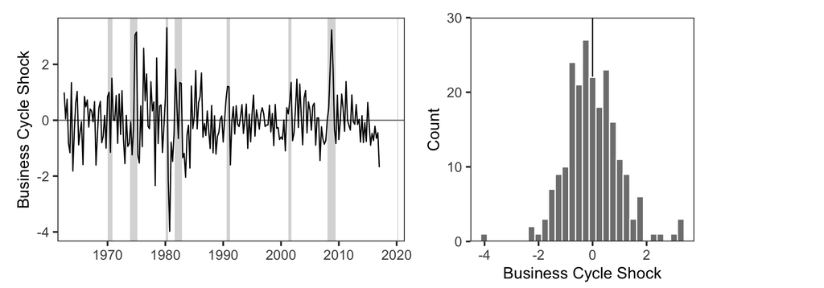

## The Main Business Cycle Shock

But the structure of the VAR means the contribution of the shock to macro variables looks like the business cycle.

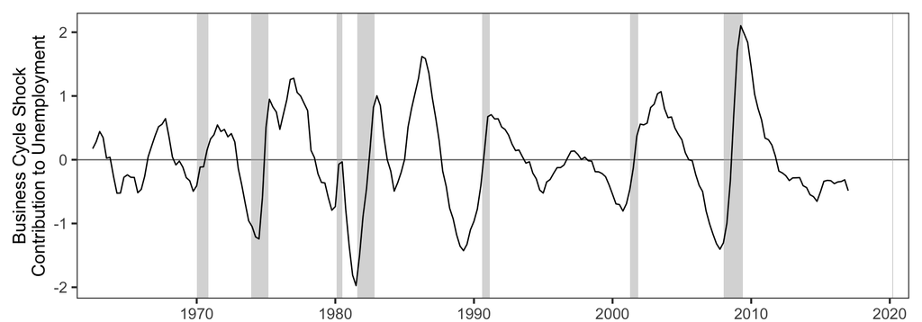

## The Main Business Cycle Shock

This business cycle shock also explains a large amount of the forecast error variance (FEV) in:

- Output, Investment, Hours Worked, and Consumption

|  | Unemployment | Output | Investment | Consumption | Hours Worked |
| --- | --- | --- | --- | --- | --- |
| Explained FEV | 77.51% | 62.99% | 64.27% | 36.49% | 67.58% |

## The Main Business Cycle Shock

If the shock was constructed targeting either

- Output, Investment, Hours Worked, or Consumption

The same “main business cycle shock” would be identified.

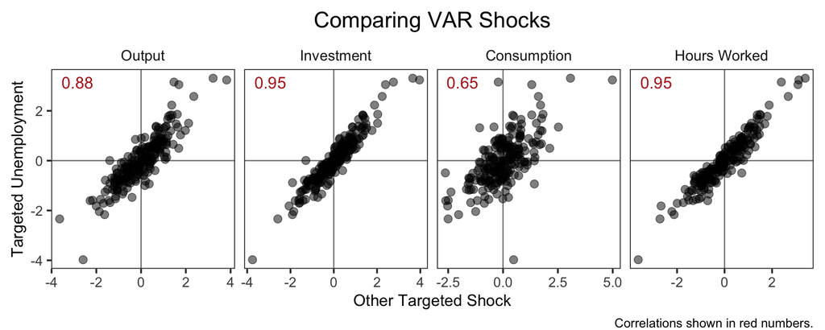

## The Main Business Cycle Shock

This is not the case for either

- Inflation or
- TFP

Thus the authors conclude that the empirical business cycle does not align well with

- RBC productivity shocks or
- New Keynesian demand shocks.

## What Drives the Co-movement?

There are two possibilities:

1. A single shock
2. A common propagation mechanism

Angeletos, Collard, and Dellas (2020) suggest it could be driven by a single shock to “higher order beliefs”.

- A type of confidence shock

We will instead show that financial conditions are a common propagation mechanism.

## Introducing the VFCI

Our preferred measure is the **volatility financial conditions index** (VFCI) constructed in Adrian, Duarte, and Iyer (2023).

The VFCI…

- is a measure of the *price of risk*
  - can be interpreted as the level of risk aversion of the aggregate housheold

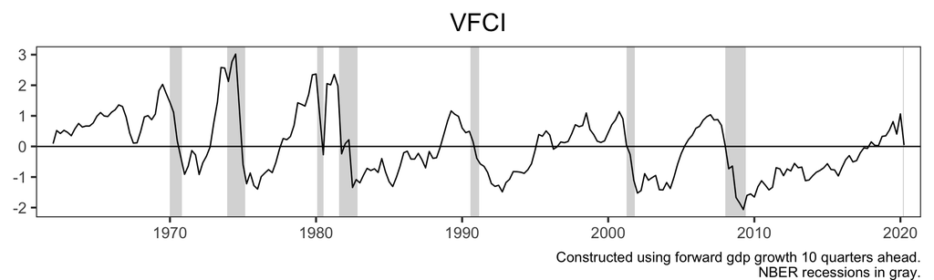

## Theory Behind the VFCI

In a NK model with financial intermediaries with a value-at-risk constraint…

- the market price of risk is a natural measure of financial conditions
- the constraint is tighter in bad times, a nonlinearity in the model.

The value-at-risk constraint links the mean and volatility of intermediaries’ net worth.

- Which, in equilibrium, links the mean and volatility of output.

**Key:** The value-at-risk constraint aggregates and propagates diverse shocks into one channel.

- Any shock changes the volatility of net worth and thus of output.

## Empirical Construction of the VFCI

Estimating the VFCI from forward GDP growth, $\Delta \text{gdp}_{t+h}$, and asset returns, $R_t$,

$$\Delta \text{gdp}_{t+h} = \theta R_t + \epsilon_t$$

Then the variance of the residual can be estimated as,

$$\log(\widehat{\epsilon}_t^2) = \delta R_t + e_t$$

Then the VFCI is defined as,

$$\text{VFCI}_t = \widehat{\delta} R_t$$

and normalized to be mean 0 and variance 1.

## Targeting VFCI Identifies Same Shock

Including VFCI in the VAR and targeting it for the max-share method returns the same business cycle shock.

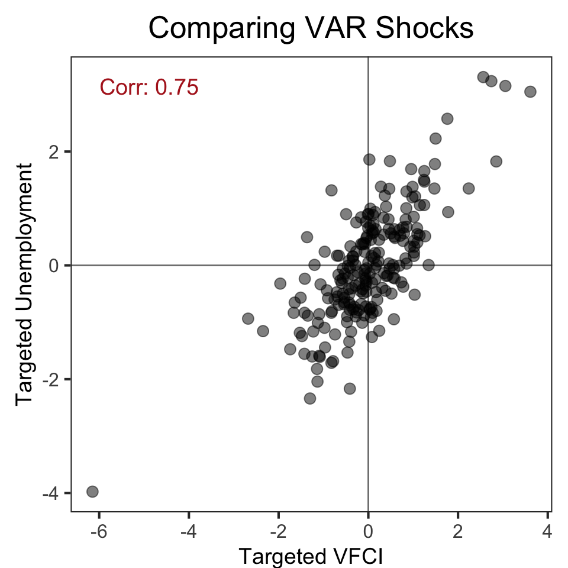

## Targeting VFCI Identifies Same Shock

The impulse response functions (IRFs) are also the same.

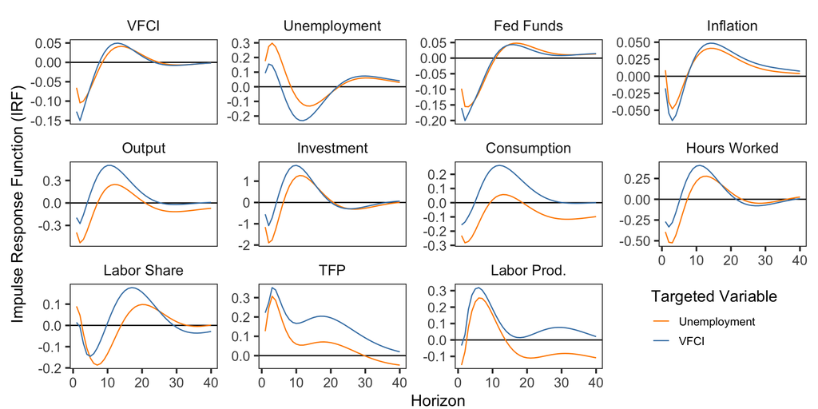

## Targeting VFCI Identifies Same Shock

And the contribution of each shock to unemployment are also similar.

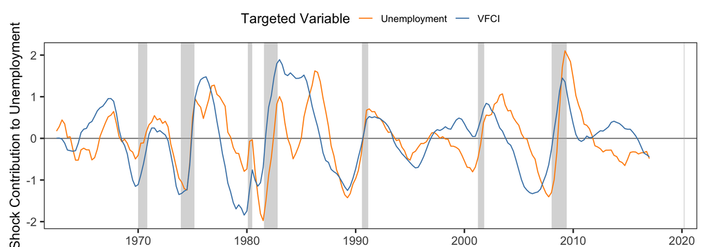

## VFCI Co-moves with the Business Cycle

We conclude that financial conditions co-move with the business cycle.

Why is a financial propagation more compelling than a single belief shock?

We also see evidence in the VAR of a strong mean-volatility relationship.

- This is present in the model with a value-at-risk constraint,
- but is not present in a model of higher order belief shocks (needs to be proven formally).

## Mean-Vol Relationship in the VAR

Taking our VAR with $p$ lags and $k$ variables in vector $y_t$,

$$y_t = A_1 y_{t-1} + \text{ ... } + A_p y_{t-p} + u_t$$

The log variance of the residual is then, $V_t = \log\left(\widehat{u}_t^2\right)$.

Then estimate,

$$V_t = \alpha_1 y_{t-1} + \text{ ... } + \alpha_p y_{t-p} + \epsilon_t$$

The mean-vol relationship is between $\widehat{y}_t$ and $\widehat{V}_t$.

There are $k$ mean-vol relationships in the VAR, one for each variable.

## Mean-Vol Relationship in the VAR

Using unemployment, we can see a strong linear relationship between the conditional mean and the conditional volatility.

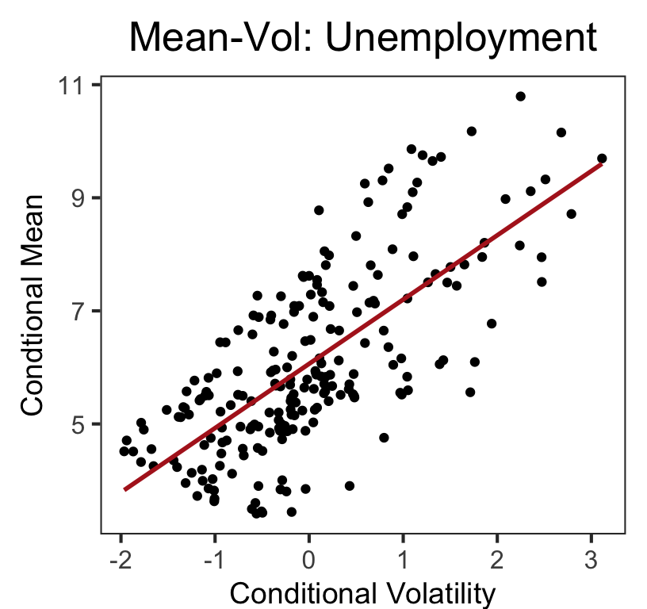

Mean-Vol for Output

## Financial Conditions Propagating the Business Cycle

There exists a general equilibrium structural model that is consistent with

- the existence of the mean-vol relationship in the empirical data,
- and that financial conditions move strongly with the business cycle,

implying financial conditions are a likely propagation mechanism.

If this is true, we would also expect a shock to financial conditions to generate the same business cycle dynamics.

## A Shock to VFCI

If we assume a Choleskey idenfication with VFCI ordered first, then a shock to VFCI generates the same business cycle dynamics.

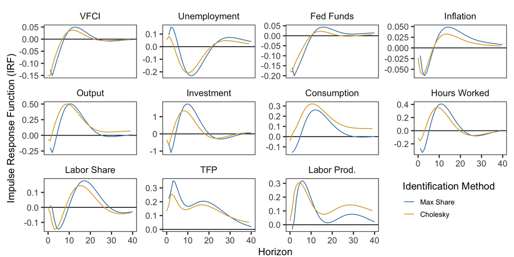

## Conclusion

Empirical facts of the business cycle are better explained by a common propagation mechanism through the financial sector.

- financial conditions move with the business cycle
- model with value-at-risk contstraint generates the empirically observed mean-volatility relationship
- financial condition shocks generate the same busines cycle

# Appendix

## Appendix: Max-Share Method Details

A SVAR(p) model with $p$ lags, for a vector of variables, $x_t$,

$$B_0 x_t = B_1 x_{t-1} + . . . + B_p x_{t-p} + \epsilon_t$$

Empirically, only the following $A_i$ matrices and reduced form residuals, $\nu_t$, are observed,

$$x_t = \underbrace{B_0^{-1}B_1}_{A_1} x_{t-1} + \dots + \underbrace{B_0^{-1}B_p}_{A_p} x_{t-p} + \underbrace{B_0^{-1}\epsilon_t}_{\upsilon_t}$$

The identification problem is determining $B_0$.

$$\nu_t = B_0^{-1} \epsilon_t$$

## Appendix: Max-Share Method Details

Compute the forecast error for one target variable (i.e. $u$) for target horizon, $h$

$$F_{t+h} = x^{(u)}_{t+h} - x^{(u)}_{t+h \mid t} = \sum_{i=0}^{h-1} \underbrace{\Gamma_i}_{IRF} B_0^{(u)^{-1}} \epsilon_{t+h+i}$$

Choose vector $B_0^{(u)}$ to maximize the variance of $F_{t+h}$,

$$\max_{B_0^{(u)}} \ \ \ \text{Var}[F_{t+h}]$$

This will identify **one** shock, up to a change of sign.

$$\epsilon_t^{u} = B_0^{(u)} \hat{\upsilon}_t$$

For business cycle shock, calculate forecast errors over a frequency range, 6 to 32 quarters.

## Appendix: Business Cycle Lengths

The shaded area shows the defined business cycle range of 6 to 32 quarters.

The box plot shows the actual distribution of business cycle lengths since 1950.

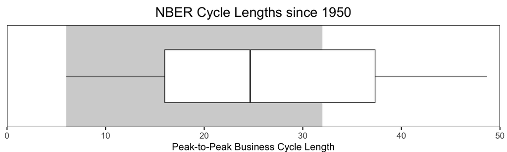

Back

## Appendix: Mean-Vol Relationship in VAR

Using output instead.

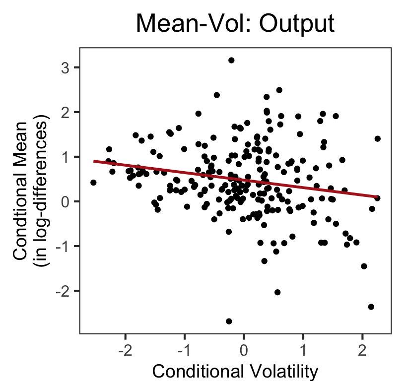

Back